# Relationship between extreme power outage events and low-income populations

Shenyue Jia

This notebook creates a scatterplot showing the relationship between the extreme power outage events in California, 2019 and low-income population (defined as 200% below federal poverty line). Extreme power outage events are defined as a power outage lasts for more than 24 hours. Low-income population is derived from [HRSA UDPMapper](https://udsmapper.org/).

```r
rm(list = ls())
```

# Data preparation

- Prepare California county-level extreme outages and cumulatively % of affected households

```r
ca_outage <- read_csv(here("result", "power-outage-events",
                           "ca_pct_household_oop_new_def.csv"))
ca_outage_24plushrs <- ca_outage %>%
  filter(Duration>24*60) %>%
  group_by(County) %>%
  summarise(SumPctHU = sum(PctHU)) %>%
  complete(County,fill=list(SumPctHU=0))
```

- Prepare California county-level data from a pre-pared Shapefile
  - County-level metrics from census
  - County-level metrics from HHS emPOWER platform on DME users and Medicare beneficiaries
  - County-level metrics from HRSA UDSMapper on healthcare resources availability

```r
ca_geo <- read_sf(here("data_private",
                       "ca_county_census_empower_UDSMapper_combined.shp"))
```

# Clean variables and prepare normalized variables

- Convert selected variables from `ca_geo` to normalized versions

```r
ca_geo_sub <- ca_geo %>%
  mutate(pct_low_income = round((1-pene_low_i)*100,2)) %>%
  select(STATEFP,COUNTYFP,GEOID,NAME,x_map,y_map,
         SumMaxCust,pct_low_income,TOTHU_CY_1) %>%
  mutate(avg_outage_customer = SumMaxCust/TOTHU_CY_1)
```

# Visualization

- Prepare a function to create beautiful breaks

```r
  calculate_class <- function(var,nclass,roundto){
    class_brks <- classInt::classIntervals(var, n = nclass,intervalClosure = "left",
                                 style = "equal")
    class_brks <- class_brks$brks
    class <- plyr::round_any(class_brks,roundto)

    return(class)
  }
```

- Annotate counties with both metrics high

```r
ca_geo_sub$label <- NA

ca_geo_sub %<>%
  mutate(label = ifelse((avg_outage_customer>0.5 &
           pct_low_income>25),NAME,NA))
```

- Add fill color for labels by region

```r
ca_region <-
  read_csv(here("data_private","california_regions.csv")) %>%
    mutate(NAME = substr(COUNTY, 1, nchar(COUNTY)-nchar(" County")))
```

- Setup colors for regions

```r
reg_hex_code <- c("#FCB0AF","#F8F892","#C2E5A4","#66B460","#EB984E","#AED6F1")
reg_hex_code_2 <- c("#C2E5A4","#66B460","#FCB0AF","#F8F892","#EB984E","#AED6F1")
```

Join the region color to ca_geo_sub

```r
ca_geo_sub <- left_join(ca_geo_sub, ca_region,by="NAME") %>%
  mutate(bold_label = ifelse(label %in% c("Plumas","Shasta","Butte","Tehama","Sierra"),
                       label,NA),
    label = ifelse(label %in% c("Plumas","Shasta","Butte","Tehama","Sierra"),
                       NA,label))
```

- Create a scatterplot with selected counties labeled

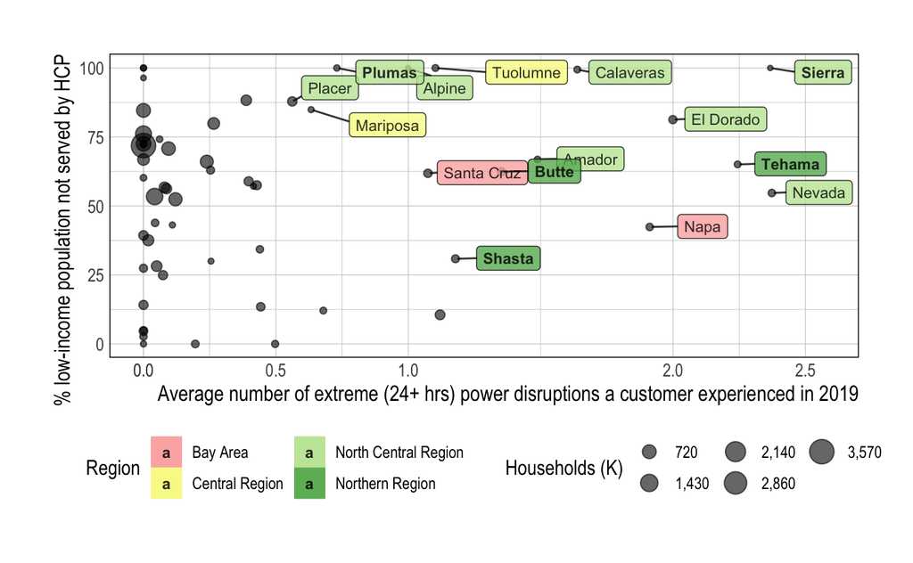

```r
scatterplot <-
            ggplot(data = ca_geo_sub,
                aes(
                    x = avg_outage_customer,
                    y = pct_low_income
                )
            ) +
              theme_ipsum()+
              theme(panel.border = element_rect(linetype = "solid", fill = NA),
                    axis.text.x = element_text(size=10),
                    axis.text.y = element_text(size=10),
                    axis.title.x = element_text(size=12),
                    axis.title.y = element_text(size=12))+
              geom_point(alpha = .6, aes(size=TOTHU_CY_1)) +
             ggrepel::geom_label_repel(
                aes(label = label,fill=REGION),nudge_x = .2,nudge_y = .2,
                min.segment.length = .2, size = 3, alpha = 0.8)+
                scale_size_continuous(name = "Households (K)", breaks =
                          calculate_class(ca_geo_sub$TOTHU_CY_1,5,10000),
                labels=formatC(calculate_class(ca_geo_sub$TOTHU_CY_1,5,10000)/1000,
                big.mark=",")
                )+
              ggrepel::geom_label_repel(
                aes(label = bold_label,fill=REGION),fontface = 'bold',nudge_x = .2,nudge_y = .2,
                min.segment.length = .2, size = 3, alpha = 0.8)+
                # scale_color_identity() +
              theme(legend.position = "bottom")+
              guides(size=guide_legend(nrow = 2),
                     fill=guide_legend(nrow = 2))+
              scale_fill_manual(name = 'Region',
                                values=reg_hex_code,
                                breaks = c('Bay Area','Central Region','North Central Region','Northern Region'))+
                scale_x_continuous("Average number of extreme (24+ hrs) power disruptions a customer experienced in 2019",breaks = c(0,calculate_class(ca_geo_sub$avg_outage_customer,4,0.5)),
                                   labels = format(c(0,calculate_class(ca_geo_sub$avg_outage_customer,4,0.5)),
                                                   big.mark = ",")) +
                scale_y_continuous("% low-income population not served by HCP",
                                   breaks = calculate_class(ca_geo_sub$pct_low_income,4,5),
                                   labels = calculate_class(ca_geo_sub$pct_low_income,4,5))

scatterplot
```

- Try a different way of labeling using `geom_label`
  - Add a new field with all labels regardless of `fontface`
  - Add a new field `face` to set up `fontface`

```r
ca_geo_sub <- ca_geo_sub %>%
    mutate(face = ifelse(is.na(bold_label),'plain','bold'),
           label_full = ifelse(is.na(bold_label),label,bold_label))
```

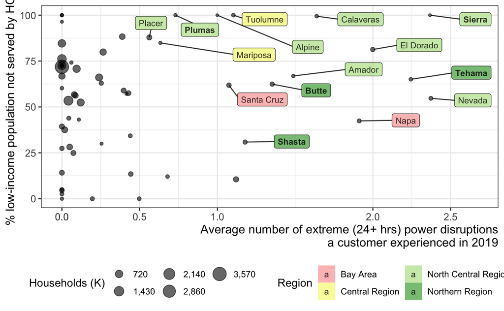

```r
scatterplot <-
            ggplot(data = ca_geo_sub,
                aes(
                    x = avg_outage_customer,
                    y = pct_low_income
                )
            ) +
              geom_point(alpha = .6, aes(size=TOTHU_CY_1)) +
             ggrepel::geom_label_repel(
                aes(label = label_full,fill=REGION,fontface = face),
                box.padding = 0.5,
                nudge_x = 0.3,nudge_y =0.3,
                min.segment.length = .2, size = 3, alpha = 0.8)+
                scale_size_continuous(name = "Households (K)", breaks =
                          calculate_class(ca_geo_sub$TOTHU_CY_1,5,10000),
                labels=formatC(calculate_class(ca_geo_sub$TOTHU_CY_1,5,10000)/1000,
                big.mark=",")
                )+
    theme_bw()+
              theme(panel.border = element_rect(linetype = "solid", fill = NA),
                    axis.text.x = element_text(size=10),
                    axis.text.y = element_text(size=10),
                    axis.title.x = element_text(size=12,hjust=1),
                    axis.title.y = element_text(size=12),
                    plot.margin = unit(c(2,2,2,2), "mm"),
                    legend.position = "bottom")+
              guides(size=guide_legend(nrow = 2,order=1),
                     fill=guide_legend(nrow = 2),order=2)+
              scale_fill_manual(name = 'Region',
                                values=reg_hex_code,
                                breaks = c('Bay Area','Central Region','North Central Region','Northern Region'))+
                scale_x_continuous("Average number of extreme (24+ hrs) power disruptions\na customer experienced in 2019",breaks = c(0,calculate_class(ca_geo_sub$avg_outage_customer,4,0.5)),
                                   labels = format(c(0,calculate_class(ca_geo_sub$avg_outage_customer,4,0.5)),
                                                   big.mark = ",")) +
                scale_y_continuous("% low-income population not served by HCP",
                                   breaks = calculate_class(ca_geo_sub$pct_low_income,4,5),
                                   labels = calculate_class(ca_geo_sub$pct_low_income,4,5))

scatterplot
```

- Save the figure as a PDF

```r
ggsave(
  here("plot", "06_scatter_extreme_poweroutage_low_income_nodist.pdf"),
  plot = scatterplot,
  width = 7,
  height = 5,
  # dpi = 200,
  scale = 1
)
```